# QC BAM Files (Work in Progress)

Sehrish Kanwal

Tue 2018-Apr-24

This report documents the work undertaken for QC for star bam and kallisto’s psedobam.

### Extract unmapped reads from bam file

For QC check, it might be a good idea to clean-up the data first by removing unmapped reads from the bam file.

The command used is:

```
samtools view -b -F 4 input.bam > output.mapped.bam
    -b output bam file
    -F Do not output alignments with any bits set in INT present in the FLAG field.
     4 SAM flag value for read unmapped
```

The output file for star and kallistto are located under (respectively):

```
/data/cephfs/punim0010/projects/Kanwal_RNASeq_Testing/seqc-test/rna-seq/work/align/RNA-Test-kallisto/RNA-Test-kallisto_star/RNA-Test-kallisto.mapped.bam

/data/cephfs/punim0010/projects/Kanwal_RNASeq_Testing/seqc-test/rna-seq/work/kallisto/RNA-Test-kallisto/pseudoalignment/pseudoalignments.sorted.mapped.bam
```

*Note*:

Interestingly, kallisto bam file had more un-mapped reads as the file size reduced from 2.1G to 1.4G. On the other hand, star bam file remained roughly the same size (2.2G -> 2.1G). Need to investigate this further.

Running `samtools flagstats` on star bam file produces the following output.

```
48967081 + 0 in total (QC-passed reads + QC-failed reads)
3077887 + 0 secondary
26247 + 0 supplementary
0 + 0 duplicates
48231706 + 0 mapped (98.50% : N/A)
45862947 + 0 paired in sequencing
22931472 + 0 read1
22931475 + 0 read2
45057520 + 0 properly paired (98.24% : N/A)
45127464 + 0 with itself and mate mapped
108 + 0 singletons (0.00% : N/A)
32314 + 0 with mate mapped to a different chr
32314 + 0 with mate mapped to a different chr (mapQ>=5)
```

98.5% of the total reads are mapped (which explains why the difference of size after removing unmapped reads is negligible).

Running `samtools flagstats` on kallisto ba, produces the following output.

```
49077810 + 0 in total (QC-passed reads + QC-failed reads)
3214860 + 0 secondary
0 + 0 supplementary
0 + 0 duplicates
38828548 + 0 mapped (79.12% : N/A)
45862950 + 0 paired in sequencing
22931475 + 0 read1
22931475 + 0 read2
35252004 + 0 properly paired (76.86% : N/A)
35252004 + 0 with itself and mate mapped
361684 + 0 singletons (0.79% : N/A)
0 + 0 with mate mapped to a different chr
0 + 0 with mate mapped to a different chr (mapQ>=5)
```

79.12% of the total reads are mapped (which further explains why there is a significant difference in sizes of the file after removing unmapped reads).

### FastQC

The summary of the FastQC result for both bam files is shown below.

| Summary | Star-Bam | Kallisto-Bam |
| --- | --- | --- |
| `Basic Statistics` | PASS | PASS |
| `Per base sequence quality` | PASS | PASS |
| `Per tile sequence quality` | PASS | PASS |
| `Per base sequence content` | FAIL | FAIL |
| `Per sequence GC content` | FAIL | FAIL |
| `Sequence Length Distribution` | PASS | PASS |
| `Overrepresented sequences` | PASS | PASS |
| `Adapter Content` | PASS | PASS |

#### Per base sequence quality in both bams look nice

*Star*

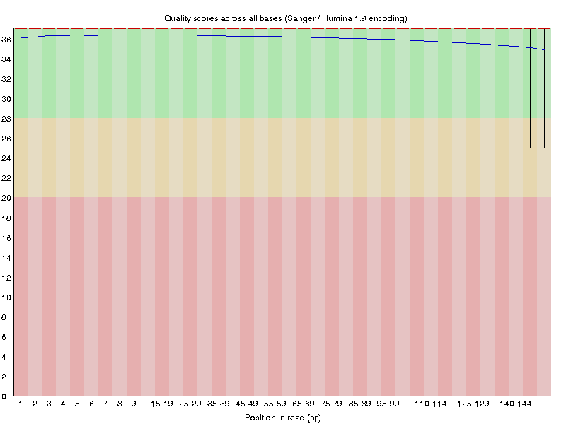

```r
knitr::include_graphics("./images/fastqc/star-base-sequence-quality.png")
```

*Kallisto*

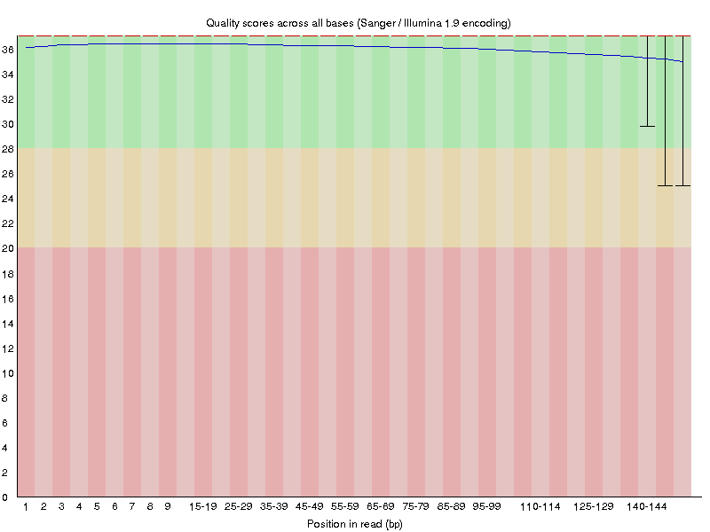

```r
knitr::include_graphics("./images/fastqc/kallisto-base-sequence-quality.png")
```

#### Including the failed matrices plots

*Star*

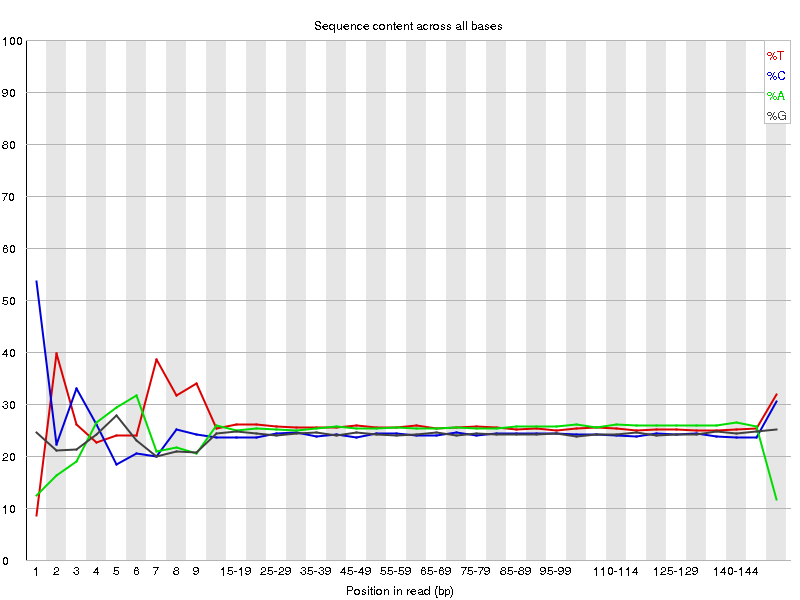

```r
knitr::include_graphics("./images/fastqc/star-base-sequence-content.png")
```

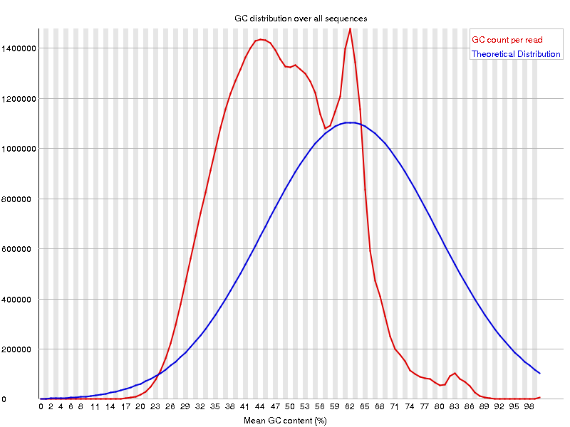

```r
knitr::include_graphics("./images/fastqc/star-GC-content.png")
```

*Kallisto*

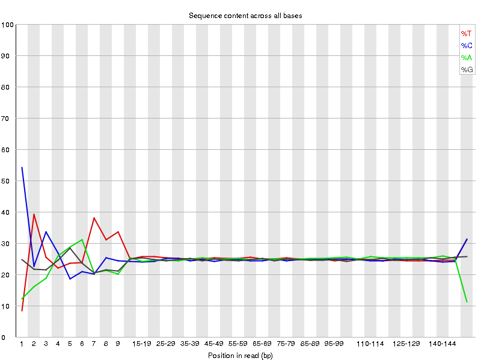

```r
knitr::include_graphics("./images/fastqc/kallisto-base-sequence-content.png")
```

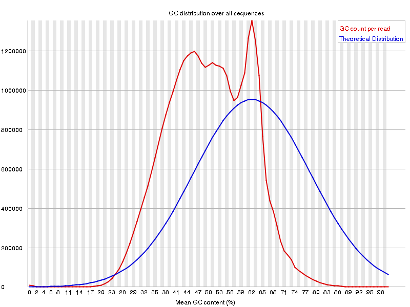

```r
knitr::include_graphics("./images/fastqc/kallisto-GC-content.png")
```